# Reproducible Research - Assignment 1

Maria Fernandez Carcedo

10 January 2016

## Introduction

This assignment makes use of data from a personal activity monitoring device. This device collects data at 5 minute intervals through out the day. The data consists of two months of data from an anonymous individual collected during the months of October and November, 2012 and include the number of steps taken in 5 minute intervals each day.

The assigment takes the form of a report that will analyse the data set described above and aswer the following questions:

## Data

#### *Dataset*

The data for this assignment can be downloaded from the course web site:

- **Dataset**: [activity.csv](https://d396qusza40orc.cloudfront.net/repdata%2Fdata%2Factivity.zip)

The variables included in this dataset are:

- **steps**: Number of steps taking in a 5-minute interval (missing values are coded as NA)
- **date**: The date on which the measurement was taken in YYYY-MM-DD format
- **interval**: Identifier for the 5-minute interval in which measurement was taken

#### *Loading and preprocessing the data*

We will dowload the data from the working directory:

```r
setwd("~/Desktop/WD")
x <-read.csv("./activity.csv", header=TRUE, sep= ",", stringsAsFactors=FALSE)
summary(x)
```

```
 steps            date              interval
```

Min. : 0.00 Length:17568 Min. : 0.0  
1st Qu.: 0.00 Class :character 1st Qu.: 588.8  
Median : 0.00 Mode :character Median :1177.5  
Mean : 37.38 Mean :1177.5  
3rd Qu.: 12.00 3rd Qu.:1766.2  
Max. :806.00 Max. :2355.0  
NA’s :2304

### 1. What is the mean total number of steps taken per day?

First of all we are going to calculate the total number of steps taken per day

```r
sum <-tapply(x$steps, x$date, sum, na.rm=TRUE)
```

Then we are going to produce an histogram of the total number of steps per day

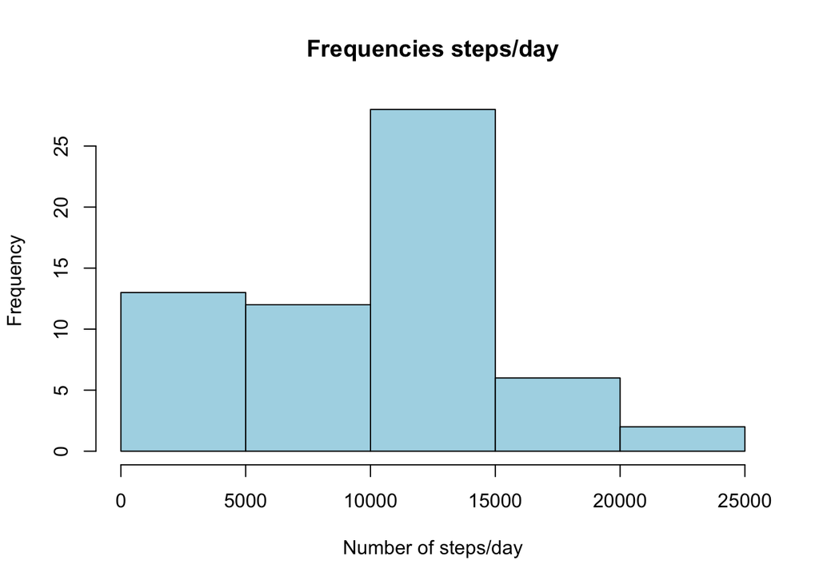

```r
hist(sum, freq=TRUE, main="Frequencies steps/day", xlab= "Number of steps/day", col="lightblue")
```

The mean and the median of the total number of steps taken per day are provided in the summary below:

```r
summary (sum)
```

```
##    Min. 1st Qu.  Median    Mean 3rd Qu.    Max.
##       0    6778   10400    9354   12810   21190
```

Thus, the mean number of steps taken per day is 9354 steps, and the median number is 10400.

### 2. What is the average daily activity pattern?

In this case we will first calculate the mean number of steps taken by interval across all days:

```r
mean <- tapply(x$steps, x$interval, mean, na.rm=TRUE)
```

And then we will produce below a 5 minute interval series plot and the average number of steps taken across all days:

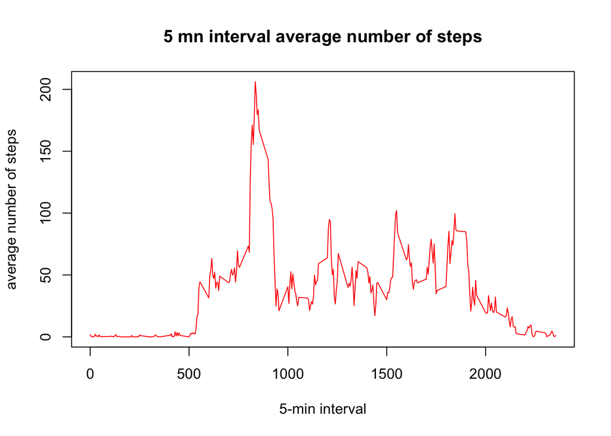

```r
plot(mean ~ unique(x$interval), type="l", main="5 mn interval average number of steps", xlab = "5-min interval", ylab="average number of steps", col="red")
```

```r
max(mean)
```

```
## [1] 206.1698
```

#### *Imputing Missing Values*

Since there are a number of days/intervals where there are missing values (coded as NA), which may introduce bias into some calculations or summaries of the data, we are going to device a strategy to imput the missing values.

In fact, as shown below, there is a significant number of 2304 missing data in the database:

```r
sum (is.na(x)==TRUE)
```

```
## [1] 2304
```

And it is to be noted that all the NA values are in the *steps* column:

```r
summary (is.na(x)==TRUE)
```

```
##    steps            date          interval
##  Mode :logical   Mode :logical   Mode :logical
##  FALSE:15264     FALSE:17568     FALSE:17568
##  TRUE :2304      NA's :0         NA's :0
##  NA's :0
```

To replace the NA values in the dataset we are going to use the mean value for the corresponding 5 mn interval instead of the missing data, and we will create a new dataset with the replacements:

```r
newx <- x
for (i in 1:nrow(x)){
   if(is.na(x$steps[i])==TRUE){
           newx$steps[i] <- mean[[as.character(x[i, "interval"])]]
   }
}
```

where the NA values are:

```r
sum (is.na(newx)==TRUE)
```

```
## [1] 0
```

And that could be represented in the following histogram of frequencies of steps per day:

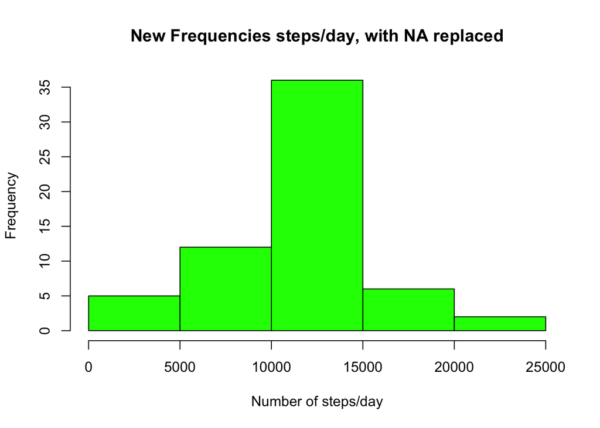

```r
sum2 <- tapply(newx$steps, newx$date, sum)
hist(sum2, freq=TRUE, main="New Frequencies steps/day, with NA replaced", xlab= "Number of steps/day", col="green")
```

With the NA values replaced the mean and median number of steps are summarized below:

```r
summary (sum2)
```

```
##    Min. 1st Qu.  Median    Mean 3rd Qu.    Max.
##      41    9819   10770   10770   12810   21190
```

Both figures overlap at 10770 steps,

thus increasing the figures that were obtained with NA values, 9354.2295082 mean of steps, and 10395 median of steps.

We are going first to convert the Date column in the data base with NA substituted into a Date and Time vector, and then into a weekdays column, obtaining a new data frame. We will use the weekdays fuction in this operation:

```r
data <- newx
{for (i in 1:17568){
        newx$date[i]<- weekdays(as.Date((newx$date[i]), origin="1970-01-01", tz="GMT"), abbreviate=FALSE)
        }
}
```

Then we will convert the days of the week in the date colum into weekday or weekend:

```r
data$date <- ifelse(data$date %in% c("Saturday", "Sunday"), "weekend", "weekday")
```

Next we create two subsets based on the two factors created: “weekend” and “weekday”

```r
library (dplyr)
sub_weekday <- filter (data, date=="weekday")
sub_weekend <- filter (data, date=="weekend")
```

We will also have to calculate the mean number of steps for each interval in both subsets, produce two data sets with three variables (interval, mean of steps and day) and combine them into one final dataset:

```r
mean_sub_weekday <- tapply(sub_weekday$steps, sub_weekday$interval, mean, na.rm=TRUE)

mean_sub_weekend <- (tapply(sub_weekend$steps, sub_weekend$interval, mean, na.rm=TRUE))

df_wday <- data.frame(interval = unique(sub_weekday$interval), avg = as.numeric(mean_sub_weekday), day = rep("weekday", length(mean_sub_weekday)))

df_wend <- data.frame(interval = unique(sub_weekend$interval), avg = as.numeric(mean_sub_weekend), day = rep("weekend", length(mean_sub_weekend)))

df_final <- rbind(df_wday, df_wend)
```

Finally, if we still have any neurones left after all… we can dedicate it to a last effort and plot, before the remains of our brain take a more revolutionary path and burst into a decided “basta ya!”

```r
library (lattice)
```

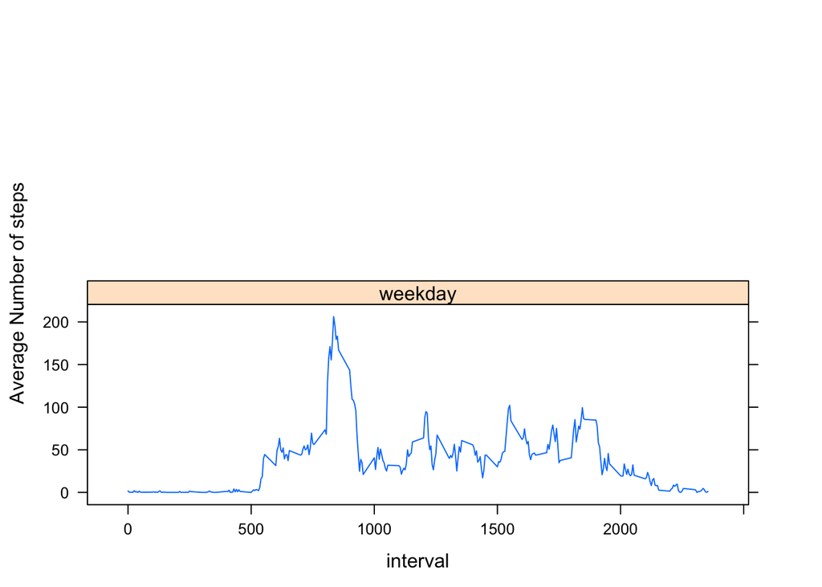

```r
xyplot(avg ~ interval | day, data = df_final, layout = c(1, 2),
       type = "l", ylab = "Average Number of steps")
```